# Final Report

Ricky Mandloi

2022-11-06

## 1.Introduction

This case study was completed by Ricky Mandloi in October 2022 as part of the Google Data Analytics Professional Certificate capstone module. R has been used to complete this case study and then hosted online through git. Each section in this document goes through all the steps taken to complete the case study.

#### 1.1 Case Study Brief

**Scenario**

You are a junior data analyst working in the marketing analyst team at Cyclistic, a bike-share company in Chicago. The director of marketing believes the company’s future success depends on maximizing the number of annual memberships. Therefore, your team wants to understand how casual riders and annual members use Cyclistic bikes differently. From these insights your team will design a new marketing strategy to convert casual riders into annual members. But first, Cyclistic executives must approve your recommendations, so they must be backed up with compelling data insights and professional data visualizations.

**About the Company**

In 2016, **Cyclistic** launched a successful bike-share offering. Since then, the program has grown to a fleet of 5,824 bicycles that are geotracked and locked into a network of 692 stations across Chicago. The bikes can be unlocked from one station and returned to any other station in the system anytime.

Until now, Cyclistic’s marketing strategy relied on building general awareness and appealing to broad consumer segments. One approach that helped make these things possible was the flexibility of its pricing plans: single-ride passes, full-day passes, and annual memberships. Customers who purchase single-ride or full-day passes are referred to as casual riders. Customer who purchase annual memberships are Cyclistic members.

Cyclistic’s finance analysts have concluded that annual members are much more profitable than casual riders. Although the pricing flexibility helps Cyclistic attract more customers, Moreno believes that **maximizing the number of annual members will be key to future growth**. Rather than creating a marketing campaign that targets all-new customers, Moreno believes there is a very good chance to **convert casual riders into members**. She notes that casual riders are already aware of the Cyclistic program and have chosen Cyclistic for their mobility needs.

Moreno has set a clear goal: **Design marketing strategies aimed at converting casual riders into annual members**. In order to do that, however, the marketing analyst team needs to better understand how annual members and casual riders differ, why casual riders would buy a membership, and how digital media could affect their marketing tactics. Moreno and her team are interested in analyzing the Cyclistic historical bike trip data to identify trends.

## 2.Prepare, Clean and Process

```r
library(tidyverse)
library(data.table)
library(lubridate)
```

**Load the data**

```r
oct21 <- read.csv("C:\\Users\\mable\\Documents\\Portfolio Projects\\001. GDA_CAPSTONE_Cyclistic\\raw_data\\202110-divvy-tripdata.csv")
nov21 <- read.csv("C:\\Users\\mable\\Documents\\Portfolio Projects\\001. GDA_CAPSTONE_Cyclistic\\raw_data\\202111-divvy-tripdata.csv")
dec21 <- read.csv("C:\\Users\\mable\\Documents\\Portfolio Projects\\001. GDA_CAPSTONE_Cyclistic\\raw_data\\202112-divvy-tripdata.csv")
jan22 <- read.csv("C:\\Users\\mable\\Documents\\Portfolio Projects\\001. GDA_CAPSTONE_Cyclistic\\raw_data\\202201-divvy-tripdata.csv")
feb22 <- read.csv("C:\\Users\\mable\\Documents\\Portfolio Projects\\001. GDA_CAPSTONE_Cyclistic\\raw_data\\202202-divvy-tripdata.csv")
mar22 <- read.csv("C:\\Users\\mable\\Documents\\Portfolio Projects\\001. GDA_CAPSTONE_Cyclistic\\raw_data\\202203-divvy-tripdata.csv")
apr22 <- read.csv("C:\\Users\\mable\\Documents\\Portfolio Projects\\001. GDA_CAPSTONE_Cyclistic\\raw_data\\202204-divvy-tripdata.csv")
may22 <- read.csv("C:\\Users\\mable\\Documents\\Portfolio Projects\\001. GDA_CAPSTONE_Cyclistic\\raw_data\\202205-divvy-tripdata.csv")
jun22 <- read.csv("C:\\Users\\mable\\Documents\\Portfolio Projects\\001. GDA_CAPSTONE_Cyclistic\\raw_data\\202206-divvy-tripdata.csv")
jul22 <- read.csv("C:\\Users\\mable\\Documents\\Portfolio Projects\\001. GDA_CAPSTONE_Cyclistic\\raw_data\\202207-divvy-tripdata.csv")
aug22 <- read.csv("C:\\Users\\mable\\Documents\\Portfolio Projects\\001. GDA_CAPSTONE_Cyclistic\\raw_data\\202208-divvy-tripdata.csv")
sep22 <- read.csv("C:\\Users\\mable\\Documents\\Portfolio Projects\\001. GDA_CAPSTONE_Cyclistic\\raw_data\\202209-divvy-publictripdata.csv")
```

**checking if structure of all data set is similar for merge**

```r
str(oct21)
```

```
## 'data.frame':    631226 obs. of  13 variables:
##  $ ride_id           : chr  "620BC6107255BF4C" "4471C70731AB2E45" "26CA69D43D15EE14" "362947F0437E1514" ...
##  $ rideable_type     : chr  "electric_bike" "electric_bike" "electric_bike" "electric_bike" ...
##  $ started_at        : chr  "2021-10-22 12:46:42" "2021-10-21 09:12:37" "2021-10-16 16:28:39" "2021-10-16 16:17:48" ...
##  $ ended_at          : chr  "2021-10-22 12:49:50" "2021-10-21 09:14:14" "2021-10-16 16:36:26" "2021-10-16 16:19:03" ...
##  $ start_station_name: chr  "Kingsbury St & Kinzie St" "" "" "" ...
##  $ start_station_id  : chr  "KA1503000043" "" "" "" ...
##  $ end_station_name  : chr  "" "" "" "" ...
##  $ end_station_id    : chr  "" "" "" "" ...
##  $ start_lat         : num  41.9 41.9 41.9 41.9 41.9 ...
##  $ start_lng         : num  -87.6 -87.7 -87.7 -87.7 -87.7 ...
##  $ end_lat           : num  41.9 41.9 41.9 41.9 41.9 ...
##  $ end_lng           : num  -87.6 -87.7 -87.7 -87.7 -87.7 ...
##  $ member_casual     : chr  "member" "member" "member" "member" ...
```

```r
str(nov21)
```

```
## 'data.frame':    359978 obs. of  13 variables:
##  $ ride_id           : chr  "7C00A93E10556E47" "90854840DFD508BA" "0A7D10CDD144061C" "2F3BE33085BCFF02" ...
##  $ rideable_type     : chr  "electric_bike" "electric_bike" "electric_bike" "electric_bike" ...
##  $ started_at        : chr  "2021-11-27 13:27:38" "2021-11-27 13:38:25" "2021-11-26 22:03:34" "2021-11-27 09:56:49" ...
##  $ ended_at          : chr  "2021-11-27 13:46:38" "2021-11-27 13:56:10" "2021-11-26 22:05:56" "2021-11-27 10:01:50" ...
##  $ start_station_name: chr  "" "" "" "" ...
##  $ start_station_id  : chr  "" "" "" "" ...
##  $ end_station_name  : chr  "" "" "" "" ...
##  $ end_station_id    : chr  "" "" "" "" ...
##  $ start_lat         : num  41.9 42 42 41.9 41.9 ...
##  $ start_lng         : num  -87.7 -87.7 -87.7 -87.8 -87.6 ...
##  $ end_lat           : num  42 41.9 42 41.9 41.9 ...
##  $ end_lng           : num  -87.7 -87.7 -87.7 -87.8 -87.6 ...
##  $ member_casual     : chr  "casual" "casual" "casual" "casual" ...
```

```r
str(dec21)
```

```
## 'data.frame':    247540 obs. of  13 variables:
##  $ ride_id           : chr  "46F8167220E4431F" "73A77762838B32FD" "4CF42452054F59C5" "3278BA87BF698339" ...
##  $ rideable_type     : chr  "electric_bike" "electric_bike" "electric_bike" "classic_bike" ...
##  $ started_at        : chr  "2021-12-07 15:06:07" "2021-12-11 03:43:29" "2021-12-15 23:10:28" "2021-12-26 16:16:10" ...
##  $ ended_at          : chr  "2021-12-07 15:13:42" "2021-12-11 04:10:23" "2021-12-15 23:23:14" "2021-12-26 16:30:53" ...
##  $ start_station_name: chr  "Laflin St & Cullerton St" "LaSalle Dr & Huron St" "Halsted St & North Branch St" "Halsted St & North Branch St" ...
##  $ start_station_id  : chr  "13307" "KP1705001026" "KA1504000117" "KA1504000117" ...
##  $ end_station_name  : chr  "Morgan St & Polk St" "Clarendon Ave & Leland Ave" "Broadway & Barry Ave" "LaSalle Dr & Huron St" ...
##  $ end_station_id    : chr  "TA1307000130" "TA1307000119" "13137" "KP1705001026" ...
##  $ start_lat         : num  41.9 41.9 41.9 41.9 41.9 ...
##  $ start_lng         : num  -87.7 -87.6 -87.6 -87.6 -87.7 ...
##  $ end_lat           : num  41.9 42 41.9 41.9 41.9 ...
##  $ end_lng           : num  -87.7 -87.7 -87.6 -87.6 -87.6 ...
##  $ member_casual     : chr  "member" "casual" "member" "member" ...
```

```r
str(jan22)
```

```
## 'data.frame':    103770 obs. of  13 variables:
##  $ ride_id           : chr  "C2F7DD78E82EC875" "A6CF8980A652D272" "BD0F91DFF741C66D" "CBB80ED419105406" ...
##  $ rideable_type     : chr  "electric_bike" "electric_bike" "classic_bike" "classic_bike" ...
##  $ started_at        : chr  "2022-01-13 11:59:47" "2022-01-10 08:41:56" "2022-01-25 04:53:40" "2022-01-04 00:18:04" ...
##  $ ended_at          : chr  "2022-01-13 12:02:44" "2022-01-10 08:46:17" "2022-01-25 04:58:01" "2022-01-04 00:33:00" ...
##  $ start_station_name: chr  "Glenwood Ave & Touhy Ave" "Glenwood Ave & Touhy Ave" "Sheffield Ave & Fullerton Ave" "Clark St & Bryn Mawr Ave" ...
##  $ start_station_id  : chr  "525" "525" "TA1306000016" "KA1504000151" ...
##  $ end_station_name  : chr  "Clark St & Touhy Ave" "Clark St & Touhy Ave" "Greenview Ave & Fullerton Ave" "Paulina St & Montrose Ave" ...
##  $ end_station_id    : chr  "RP-007" "RP-007" "TA1307000001" "TA1309000021" ...
##  $ start_lat         : num  42 42 41.9 42 41.9 ...
##  $ start_lng         : num  -87.7 -87.7 -87.7 -87.7 -87.6 ...
##  $ end_lat           : num  42 42 41.9 42 41.9 ...
##  $ end_lng           : num  -87.7 -87.7 -87.7 -87.7 -87.6 ...
##  $ member_casual     : chr  "casual" "casual" "member" "casual" ...
```

```r
str(feb22)
```

```
## 'data.frame':    115609 obs. of  13 variables:
##  $ ride_id           : chr  "E1E065E7ED285C02" "1602DCDC5B30FFE3" "BE7DD2AF4B55C4AF" "A1789BDF844412BE" ...
##  $ rideable_type     : chr  "classic_bike" "classic_bike" "classic_bike" "classic_bike" ...
##  $ started_at        : chr  "2022-02-19 18:08:41" "2022-02-20 17:41:30" "2022-02-25 18:55:56" "2022-02-14 11:57:03" ...
##  $ ended_at          : chr  "2022-02-19 18:23:56" "2022-02-20 17:45:56" "2022-02-25 19:09:34" "2022-02-14 12:04:00" ...
##  $ start_station_name: chr  "State St & Randolph St" "Halsted St & Wrightwood Ave" "State St & Randolph St" "Southport Ave & Waveland Ave" ...
##  $ start_station_id  : chr  "TA1305000029" "TA1309000061" "TA1305000029" "13235" ...
##  $ end_station_name  : chr  "Clark St & Lincoln Ave" "Southport Ave & Wrightwood Ave" "Canal St & Adams St" "Broadway & Sheridan Rd" ...
##  $ end_station_id    : chr  "13179" "TA1307000113" "13011" "13323" ...
##  $ start_lat         : num  41.9 41.9 41.9 41.9 41.9 ...
##  $ start_lng         : num  -87.6 -87.6 -87.6 -87.7 -87.6 ...
##  $ end_lat           : num  41.9 41.9 41.9 42 41.9 ...
##  $ end_lng           : num  -87.6 -87.7 -87.6 -87.6 -87.6 ...
##  $ member_casual     : chr  "member" "member" "member" "member" ...
```

```r
str(mar22)
```

```
## 'data.frame':    284042 obs. of  13 variables:
##  $ ride_id           : chr  "47EC0A7F82E65D52" "8494861979B0F477" "EFE527AF80B66109" "9F446FD9DEE3F389" ...
##  $ rideable_type     : chr  "classic_bike" "electric_bike" "classic_bike" "classic_bike" ...
##  $ started_at        : chr  "2022-03-21 13:45:01" "2022-03-16 09:37:16" "2022-03-23 19:52:02" "2022-03-01 19:12:26" ...
##  $ ended_at          : chr  "2022-03-21 13:51:18" "2022-03-16 09:43:34" "2022-03-23 19:54:48" "2022-03-01 19:22:14" ...
##  $ start_station_name: chr  "Wabash Ave & Wacker Pl" "Michigan Ave & Oak St" "Broadway & Berwyn Ave" "Wabash Ave & Wacker Pl" ...
##  $ start_station_id  : chr  "TA1307000131" "13042" "13109" "TA1307000131" ...
##  $ end_station_name  : chr  "Kingsbury St & Kinzie St" "Orleans St & Chestnut St (NEXT Apts)" "Broadway & Ridge Ave" "Franklin St & Jackson Blvd" ...
##  $ end_station_id    : chr  "KA1503000043" "620" "15578" "TA1305000025" ...
##  $ start_lat         : num  41.9 41.9 42 41.9 41.9 ...
##  $ start_lng         : num  -87.6 -87.6 -87.7 -87.6 -87.6 ...
##  $ end_lat           : num  41.9 41.9 42 41.9 41.9 ...
##  $ end_lng           : num  -87.6 -87.6 -87.7 -87.6 -87.7 ...
##  $ member_casual     : chr  "member" "member" "member" "member" ...
```

```r
str(apr22)
```

```
## 'data.frame':    371249 obs. of  13 variables:
##  $ ride_id           : chr  "3564070EEFD12711" "0B820C7FCF22F489" "89EEEE32293F07FF" "84D4751AEB31888D" ...
##  $ rideable_type     : chr  "electric_bike" "classic_bike" "classic_bike" "classic_bike" ...
##  $ started_at        : chr  "2022-04-06 17:42:48" "2022-04-24 19:23:07" "2022-04-20 19:29:08" "2022-04-22 21:14:06" ...
##  $ ended_at          : chr  "2022-04-06 17:54:36" "2022-04-24 19:43:17" "2022-04-20 19:35:16" "2022-04-22 21:23:29" ...
##  $ start_station_name: chr  "Paulina St & Howard St" "Wentworth Ave & Cermak Rd" "Halsted St & Polk St" "Wentworth Ave & Cermak Rd" ...
##  $ start_station_id  : chr  "515" "13075" "TA1307000121" "13075" ...
##  $ end_station_name  : chr  "University Library (NU)" "Green St & Madison St" "Green St & Madison St" "Delano Ct & Roosevelt Rd" ...
##  $ end_station_id    : chr  "605" "TA1307000120" "TA1307000120" "KA1706005007" ...
##  $ start_lat         : num  42 41.9 41.9 41.9 41.9 ...
##  $ start_lng         : num  -87.7 -87.6 -87.6 -87.6 -87.6 ...
##  $ end_lat           : num  42.1 41.9 41.9 41.9 41.9 ...
##  $ end_lng           : num  -87.7 -87.6 -87.6 -87.6 -87.6 ...
##  $ member_casual     : chr  "member" "member" "member" "casual" ...
```

```r
str(may22)
```

```
## 'data.frame':    634858 obs. of  13 variables:
##  $ ride_id           : chr  "EC2DE40644C6B0F4" "1C31AD03897EE385" "1542FBEC830415CF" "6FF59852924528F8" ...
##  $ rideable_type     : chr  "classic_bike" "classic_bike" "classic_bike" "classic_bike" ...
##  $ started_at        : chr  "2022-05-23 23:06:58" "2022-05-11 08:53:28" "2022-05-26 18:36:28" "2022-05-10 07:30:07" ...
##  $ ended_at          : chr  "2022-05-23 23:40:19" "2022-05-11 09:31:22" "2022-05-26 18:58:18" "2022-05-10 07:38:49" ...
##  $ start_station_name: chr  "Wabash Ave & Grand Ave" "DuSable Lake Shore Dr & Monroe St" "Clinton St & Madison St" "Clinton St & Madison St" ...
##  $ start_station_id  : chr  "TA1307000117" "13300" "TA1305000032" "TA1305000032" ...
##  $ end_station_name  : chr  "Halsted St & Roscoe St" "Field Blvd & South Water St" "Wood St & Milwaukee Ave" "Clark St & Randolph St" ...
##  $ end_station_id    : chr  "TA1309000025" "15534" "13221" "TA1305000030" ...
##  $ start_lat         : num  41.9 41.9 41.9 41.9 41.9 ...
##  $ start_lng         : num  -87.6 -87.6 -87.6 -87.6 -87.6 ...
##  $ end_lat           : num  41.9 41.9 41.9 41.9 41.9 ...
##  $ end_lng           : num  -87.6 -87.6 -87.7 -87.6 -87.7 ...
##  $ member_casual     : chr  "member" "member" "member" "member" ...
```

```r
str(jun22)
```

```
## 'data.frame':    769204 obs. of  13 variables:
##  $ ride_id           : chr  "600CFD130D0FD2A4" "F5E6B5C1682C6464" "B6EB6D27BAD771D2" "C9C320375DE1D5C6" ...
##  $ rideable_type     : chr  "electric_bike" "electric_bike" "electric_bike" "electric_bike" ...
##  $ started_at        : chr  "2022-06-30 17:27:53" "2022-06-30 18:39:52" "2022-06-30 11:49:25" "2022-06-30 11:15:25" ...
##  $ ended_at          : chr  "2022-06-30 17:35:15" "2022-06-30 18:47:28" "2022-06-30 12:02:54" "2022-06-30 11:19:43" ...
##  $ start_station_name: chr  "" "" "" "" ...
##  $ start_station_id  : chr  "" "" "" "" ...
##  $ end_station_name  : chr  "" "" "" "" ...
##  $ end_station_id    : chr  "" "" "" "" ...
##  $ start_lat         : num  41.9 41.9 41.9 41.8 41.9 ...
##  $ start_lng         : num  -87.6 -87.6 -87.7 -87.7 -87.6 ...
##  $ end_lat           : num  41.9 41.9 41.9 41.8 41.9 ...
##  $ end_lng           : num  -87.6 -87.6 -87.6 -87.7 -87.6 ...
##  $ member_casual     : chr  "casual" "casual" "casual" "casual" ...
```

```r
str(jul22)
```

```
## 'data.frame':    823488 obs. of  13 variables:
##  $ ride_id           : chr  "954144C2F67B1932" "292E027607D218B6" "57765852588AD6E0" "B5B6BE44314590E6" ...
##  $ rideable_type     : chr  "classic_bike" "classic_bike" "classic_bike" "classic_bike" ...
##  $ started_at        : chr  "2022-07-05 08:12:47" "2022-07-26 12:53:38" "2022-07-03 13:58:49" "2022-07-31 17:44:21" ...
##  $ ended_at          : chr  "2022-07-05 08:24:32" "2022-07-26 12:55:31" "2022-07-03 14:06:32" "2022-07-31 18:42:50" ...
##  $ start_station_name: chr  "Ashland Ave & Blackhawk St" "Buckingham Fountain (Temp)" "Buckingham Fountain (Temp)" "Buckingham Fountain (Temp)" ...
##  $ start_station_id  : chr  "13224" "15541" "15541" "15541" ...
##  $ end_station_name  : chr  "Kingsbury St & Kinzie St" "Michigan Ave & 8th St" "Michigan Ave & 8th St" "Woodlawn Ave & 55th St" ...
##  $ end_station_id    : chr  "KA1503000043" "623" "623" "TA1307000164" ...
##  $ start_lat         : num  41.9 41.9 41.9 41.9 41.9 ...
##  $ start_lng         : num  -87.7 -87.6 -87.6 -87.6 -87.6 ...
##  $ end_lat           : num  41.9 41.9 41.9 41.8 41.9 ...
##  $ end_lng           : num  -87.6 -87.6 -87.6 -87.6 -87.7 ...
##  $ member_casual     : chr  "member" "casual" "casual" "casual" ...
```

```r
str(aug22)
```

```
## 'data.frame':    785932 obs. of  13 variables:
##  $ ride_id           : chr  "550CF7EFEAE0C618" "DAD198F405F9C5F5" "E6F2BC47B65CB7FD" "F597830181C2E13C" ...
##  $ rideable_type     : chr  "electric_bike" "electric_bike" "electric_bike" "electric_bike" ...
##  $ started_at        : chr  "2022-08-07 21:34:15" "2022-08-08 14:39:21" "2022-08-08 15:29:50" "2022-08-08 02:43:50" ...
##  $ ended_at          : chr  "2022-08-07 21:41:46" "2022-08-08 14:53:23" "2022-08-08 15:40:34" "2022-08-08 02:58:53" ...
##  $ start_station_name: chr  "" "" "" "" ...
##  $ start_station_id  : chr  "" "" "" "" ...
##  $ end_station_name  : chr  "" "" "" "" ...
##  $ end_station_id    : chr  "" "" "" "" ...
##  $ start_lat         : num  41.9 41.9 42 41.9 41.9 ...
##  $ start_lng         : num  -87.7 -87.6 -87.7 -87.7 -87.7 ...
##  $ end_lat           : num  41.9 41.9 42 42 41.8 ...
##  $ end_lng           : num  -87.7 -87.6 -87.7 -87.7 -87.7 ...
##  $ member_casual     : chr  "casual" "casual" "casual" "casual" ...
```

```r
str(sep22)
```

```
## 'data.frame':    701339 obs. of  13 variables:
##  $ ride_id           : chr  "5156990AC19CA285" "E12D4A16BF51C274" "A02B53CD7DB72DD7" "C82E05FEE872DF11" ...
##  $ rideable_type     : chr  "electric_bike" "electric_bike" "electric_bike" "electric_bike" ...
##  $ started_at        : chr  "2022-09-01 08:36:22" "2022-09-01 17:11:29" "2022-09-01 17:15:50" "2022-09-01 09:00:28" ...
##  $ ended_at          : chr  "2022-09-01 08:39:05" "2022-09-01 17:14:45" "2022-09-01 17:16:12" "2022-09-01 09:10:32" ...
##  $ start_station_name: chr  "" "" "" "" ...
##  $ start_station_id  : chr  "" "" "" "" ...
##  $ end_station_name  : chr  "California Ave & Milwaukee Ave" "" "" "" ...
##  $ end_station_id    : chr  "13084" "" "" "" ...
##  $ start_lat         : num  41.9 41.9 41.9 41.9 41.9 ...
##  $ start_lng         : num  -87.7 -87.6 -87.6 -87.7 -87.7 ...
##  $ end_lat           : num  41.9 41.9 41.9 41.9 41.9 ...
##  $ end_lng           : num  -87.7 -87.6 -87.6 -87.7 -87.7 ...
##  $ member_casual     : chr  "casual" "casual" "casual" "casual" ...
```

**merging all data sets**

```r
all_trips <- bind_rows(oct21, nov21, dec21, jan22, feb22, mar22, apr22, may22, jun22, jul22,aug22, sep22)
```

**Change date string types**

The started_at and ended_at columns are ‘chr’ type by default, it should be changed to date type to make it easier to sort during analysis.

```r
all_trips$started_at <- ymd_hms(all_trips$started_at)
all_trips$ended_at <- ymd_hms(all_trips$ended_at)
```

**Calculate ride length**

```r
all_trips$trip_length <- (as.double(as.character(difftime(all_trips$ended_at, all_trips$started_at, units = "secs"))))/60
```

**Add relevant columns to help summarise by date variables**

```r
all_trips$date <- as.Date(all_trips$started_at)
all_trips$month <- format(all_trips$started_at,"%m")
all_trips$day <- format(all_trips$started_at,"%d")
all_trips$day_of_week <- format(all_trips$started_at,"%A")
all_trips$time_of_day <- format(all_trips$started_at,"%H:%M:%S")
```

#### 2.2 Clean Dataset

**Remove blank results**

```r
all_trips_clean <- drop_na(all_trips)

all_trips_clean <- all_trips_clean %>%
  filter(!(is.na(start_station_name) | start_station_name == ""))%>%
  filter(!(is.na(end_station_name) | end_station_name == ""))
```

**Remove duplicates**

```r
all_trips_clean <- distinct(all_trips_clean)
```

**Remove negative trip length and trips longer than one day**

```r
all_trips_clean <- all_trips_clean %>%
  filter(!(trip_length < 1))%>%
  filter(!(trip_length>1440))
```

#### 2.3 Process data set for easier analysis

**arrange week days in order**

```r
all_trips_clean$day_of_week <- ordered(
  all_trips_clean$day_of_week,
  levels = c(
    "Monday", "Tuesday", "Wednesday", "Thursday",
    "Friday", "Saturday", "Sunday"
  )
)
```

**change time_of_day column type to date type**

```r
all_trips_clean$time2 <- as.POSIXct(all_trips_clean$time_of_day, format = "%H:%M")
```

**Save the cleaned dataset**

```r
fwrite(all_trips_clean,
       "C:\\Users\\mable\\Documents\\Portfolio Projects\\001. GDA_CAPSTONE_Cyclistic\\Analysis\\all_trips_clean.csv",
       col.names = TRUE, row.names = FALSE)
```

## 3.Analysis

In this section it’s time to analyze the data and extract key information and plot/visualize it so that we can use it to make data driven decisions.

**load clean data**

```r
all_trips_clean <- fread("C:\\Users\\mable\\Documents\\Portfolio Projects\\001. GDA_CAPSTONE_Cyclistic\\Analysis\\all_trips_clean.csv")
```

**Number of trips broken down by customer type**

```r
table(all_trips_clean$member_casual)
```

```
##
##  casual  member
## 1780010 2619987
```

We can see here that members on average takes 47.1% more trips compared to casual members.

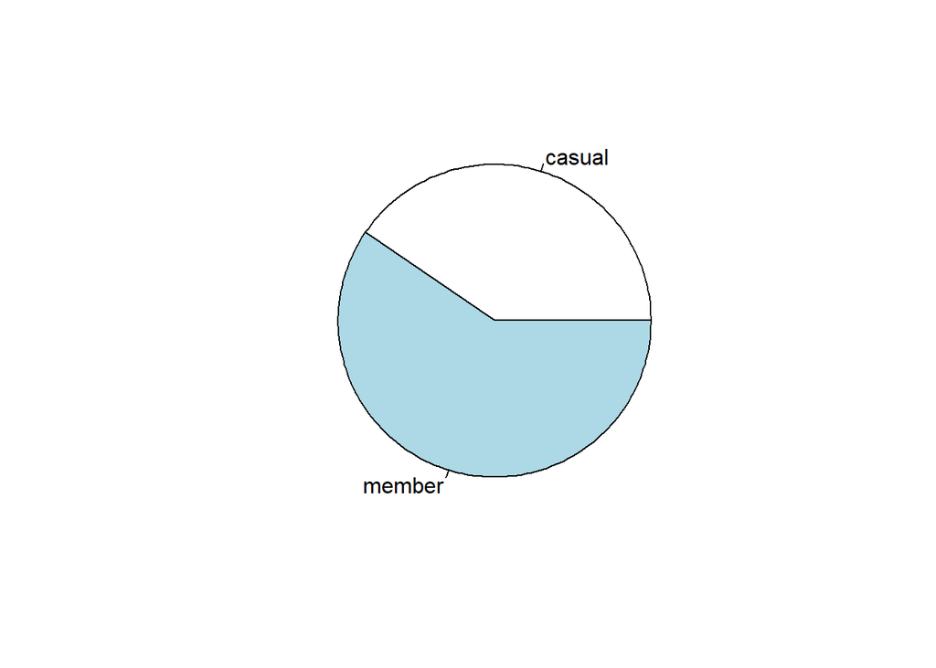

```r
pie(table(all_trips_clean$member_casual))
```

**Total trip length broken down by customer type**

```r
aggregate(trip_length ~ member_casual, all_trips_clean, sum)
```

```
##   member_casual trip_length
## 1        casual    43778773
## 2        member    33257182
```

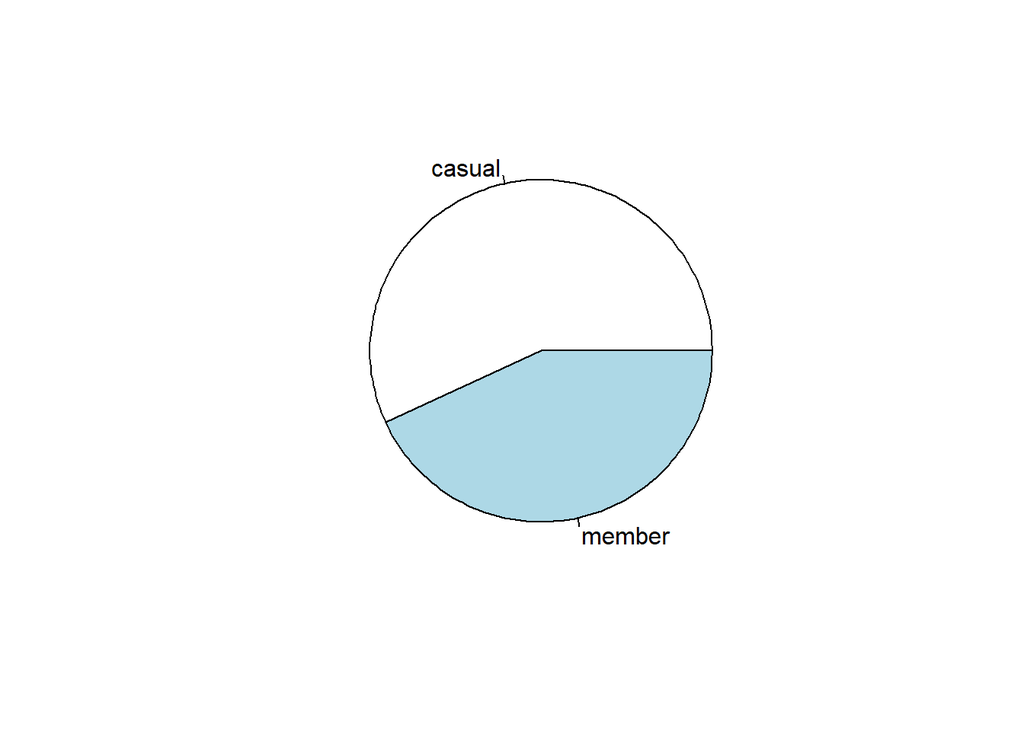

```r
pie(aggregate(trip_length ~ member_casual, all_trips_clean, sum)$trip_length, labels = all_trips_clean$member_casual)
```

In total casual member’s trip last longer than members.

**Summary of trip length based on customer type**

```r
all_trips_clean %>%
  group_by(member_casual)%>%
  summarise(min(trip_length), max(trip_length), median(trip_length), mean(trip_length))
```

```
## # A tibble: 2 × 5
##   member_casual `min(trip_length)` `max(trip_length)` median(trip_leng…¹ mean(…²
##   <chr>                      <dbl>              <dbl>              <dbl>   <dbl>
## 1 casual                         1              1439.              14.5     24.6
## 2 member                         1              1435.               9.22    12.7
## # … with abbreviated variable names ¹`median(trip_length)`,
## #   ²`mean(trip_length)`
```

```r
setNames(aggregate(all_trips_clean$trip_length ~ all_trips_clean$member_casual + all_trips_clean$day_of_week, FUN = median), c('trip_length', 'member_casual', 'day_of_week'))
```

```
##    trip_length member_casual day_of_week
## 1       casual        Monday   14.516667
## 2       member        Monday    8.833333
## 3       casual       Tuesday   12.716667
## 4       member       Tuesday    8.816667
## 5       casual     Wednesday   12.616667
## 6       member     Wednesday    8.950000
## 7       casual      Thursday   12.816667
## 8       member      Thursday    8.950000
## 9       casual        Friday   13.700000
## 10      member        Friday    9.066667
## 11      casual      Saturday   16.666667
## 12      member      Saturday   10.383333
## 13      casual        Sunday   16.800000
## 14      member        Sunday   10.116667
```

**Total number of trips broken down by day of the week and customer type**

```r
all_trips_clean %>%
  group_by(member_casual, day_of_week)%>%
  summarise(total_rides = n(), avg_trip = mean(trip_length))%>%
  arrange(day_of_week)
```

```
## # A tibble: 14 × 4
## # Groups:   member_casual [2]
##    member_casual day_of_week total_rides avg_trip
##    <chr>         <ord>             <int>    <dbl>
##  1 casual        Monday           206949     25.3
##  2 member        Monday           366832     12.3
##  3 casual        Tuesday          200033     22.1
##  4 member        Tuesday          421046     12.0
##  5 casual        Wednesday        203391     21.2
##  6 member        Wednesday        415781     12.1
##  7 casual        Thursday         221785     21.7
##  8 member        Thursday         404933     12.2
##  9 casual        Friday           255947     23.0
## 10 member        Friday           370537     12.4
## 11 casual        Saturday         382572     27.3
## 12 member        Saturday         344196     14.3
## 13 casual        Sunday           309333     28.1
## 14 member        Sunday           296662     14.2
```

**Total number of rides per month broken down by customer type**

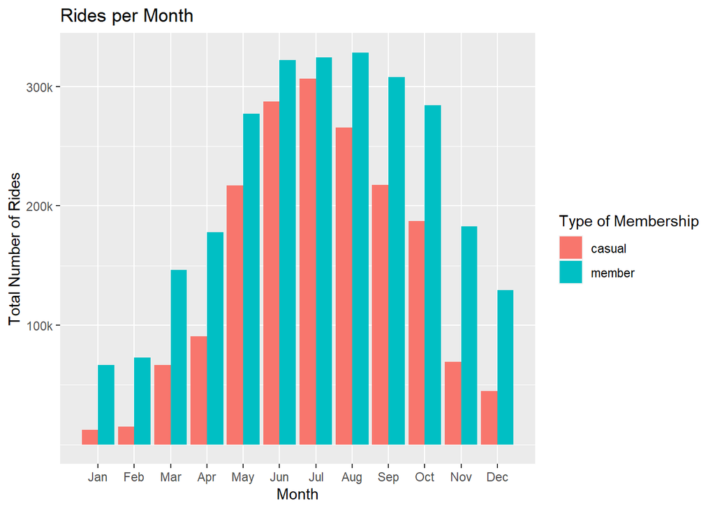

```r
all_trips_clean %>%
  group_by(member_casual, month)%>%
  summarise(total_rides = n(), 'avg_duration(mins)' = mean(trip_length))%>%
  arrange(member_casual)%>%
  ggplot(aes(x=month, y = total_rides, fill = member_casual))+
  geom_col(position = "dodge")+
  labs(x = "Month", y = "Total Number of Rides", title = "Rides per Month", fill = "Type of Membership")+
  scale_y_continuous(breaks = c(100000, 200000, 300000, 400000), labels = c("100k", "200k", "300k", "400k"))+
  scale_x_discrete(limits = 1:12, labels = month.abb)
```

The graph shows that the summer months are the most popular time of year for Cyclistic. Grouping the graph by casual and member riders shows that members use Cyclistic service more consistently throughout the year, whereas casual riders tend to only use the bike service during the summer months.

**Average trip length per day of week broken down by customer type**

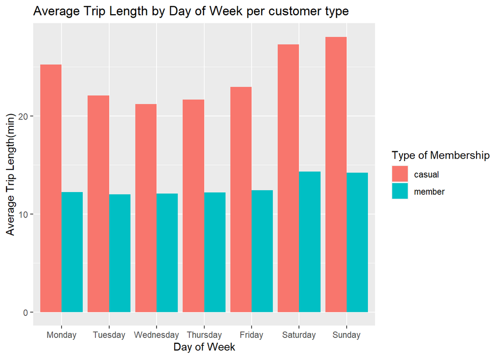

```r
all_trips_clean %>%
  group_by(member_casual, day_of_week) %>%
  summarise(average_trip_length = mean(trip_length)) %>%
  ggplot(aes(x=day_of_week, y = average_trip_length, fill = member_casual))+
  geom_col(position = "dodge") +
  labs (x="Day of Week", y="Average Trip Length(min)", title = "Average Trip Length by Day of Week per customer type", fill = "Type of Membership")
```

**Total rides broken down by day of week**

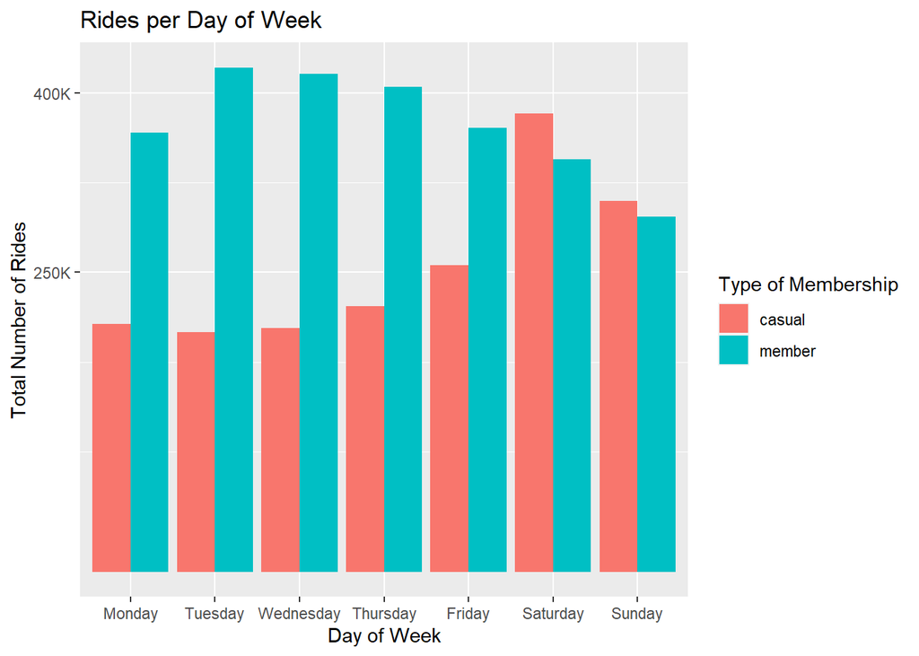

```r
all_trips_clean %>%    #total rides broken down by weekday
  group_by(member_casual, day_of_week) %>%
  summarise(number_of_rides = n() ) %>%
  arrange(member_casual, day_of_week) %>%
  ggplot(aes(x = day_of_week, y = number_of_rides, fill = member_casual)) +
  geom_col(position = "dodge") +
  labs(x= 'Day of Week', y='Total Number of Rides', title='Rides per Day of Week', fill = 'Type of Membership') +
  scale_y_continuous(breaks = c(250000, 400000, 550000), labels = c("250K", "400K", "550K"))
```

**Total Trips Throughout the Day**

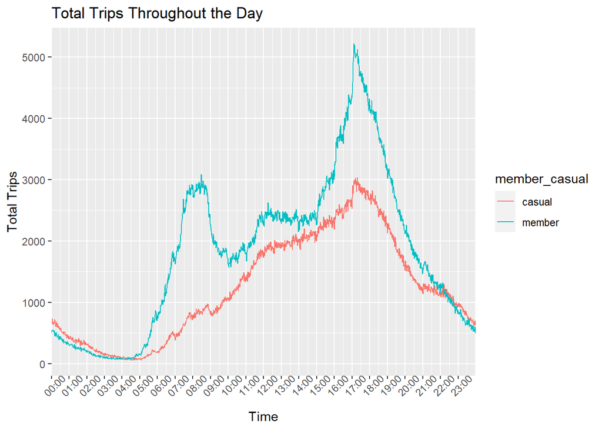

```r
all_trips_clean%>%
  group_by(member_casual, time_of_day)%>%
  summarise(total_trips = n())%>%
  ggplot(aes(x = time_of_day, y = total_trips, color = member_casual, group = member_casual))+
  geom_line()+
  scale_x_datetime(date_breaks = "1 hour", date_labels = "%H:%M", expand = c(0,0))+
  theme(axis.text.x = element_text(angle = 45)) +
  labs(title ="Total Trips Throughout the Day", x = "Time", y = "Total Trips")
```

on the other hand, Casual user are not as inconsistent as there is a steady increase throughout the day with a steady decrease after the peak at 5pm.

## 4.Conclusion

1. Annual members mainly use the bikes for their commutes, as their use peak at start and end of work hours.
2. Casual user use the bikes more for leisure, as their use peak during the weekend and summer months.
3. Casual user do not use the service during the winter months as much as annual members.
4. Casual user ride nearly double in time compared to members on average.

## 5.Recommendations

1. based on the analysis, It is recommended to run the marketing campaign during the summer months, starting from May when we start seeing increase in service use. it should run at least for 4 month (till August) as these are the peak usage months.
2. Saturday and Sunday should be prioritized for the campaign as during the weekend casual riders are at peak usage.
3. A weekend only membership can persuade more casual users to try the membership.